# Basics of R

12/21/2018

# 1. Introduction to R

## a. What is R?

R is an open source programming language designed for statistical computing & graphics.

- Free to use
- Reproducible
- Community support
- Great libraries
- Diverse industries (health, academia to business sector)

Note: *Whatever you’re trying to do, you’re probably not the first to try doing it R. Chances are good that someone has already written a package for that.*

## b. Creating a New file

1. Go to File > R Script

[figure not shown]

# 2. Basics of R

## a. R as Calculator

```r
# ADD
5 + 10
```

```
## [1] 15
```

```r
# Subtract
15 - 5
```

```
## [1] 10
```

```r
# Multiply
5 * 10
```

```
## [1] 50
```

```r
# Divide
100 / 5
```

```
## [1] 20
```

## b. Function

A function performs a specific task when called.

### Types of Function:

| Types | Functions |
| --- | --- |
| Built-in | print(), sum(), mean() |
| User-defined | eg: add.me() |

```r
# print your name
print("My name is Binod")  # what's yours?
```

```
## [1] "My name is Binod"
```

```r
#add 1 to 100
sum(1:100)
```

```
## [1] 5050
```

```r
# mean of 5, 10, 15
mean(5, 10, 15)
```

```
## [1] 5
```

```r
# median
median(c(5, 10, 15))
```

```
## [1] 10
```

```r
# answer
sum(5, 10, 15)/3
```

```
## [1] 10
```

```r
# square root
sqrt(16)
```

```
## [1] 4
```

```r
# User-defined function - add.me()

add.me <- function (x, y) {
   print(x + y)
}

add.me(1, 2)
```

```
## [1] 3
```

## c. Assignment

- Process to store values
- The <- operator is used for assignment.
- We assign values in a variable.

```r
total <- sum(1:50)
total
```

```
## [1] 1275
```

```r
avg <- mean(5, 10, 15)
avg
```

```
## [1] 5
```

## d. Mutiplication Table

```r
num = as.integer(readline(prompt = "Type a number: "))
```

```
## Type a number:
```

```r
for(i in 1:10) {
  print(paste(num,'x', i, '=', num * i))
}
```

```
## [1] "NA x 1 = NA"
## [1] "NA x 2 = NA"
## [1] "NA x 3 = NA"
## [1] "NA x 4 = NA"
## [1] "NA x 5 = NA"
## [1] "NA x 6 = NA"
## [1] "NA x 7 = NA"
## [1] "NA x 8 = NA"
## [1] "NA x 9 = NA"
## [1] "NA x 10 = NA"
```

# 3. Data Structures in R

To make best out of R, you need solid basics of data structures and how to operate on those.

To understand computations in R, two slogans are helpful:

- Everything that exists is an object.
- Everything that happens is a function call.

| Dimension | Type |  |
| --- | --- | --- |
| - | Homogeneous | Heterogeneous |
| 1D | Vector | List |
| 2D | Matrix | Data Frame |
| nD | Array* | - |

Note: Homogeneous allow only single data types.

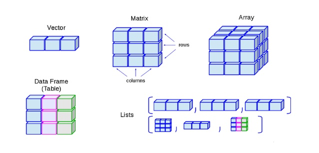

## 3.1 Vector

Vector is one-directional sequence of elements having same data types.

| Type | Example |
| --- | --- |
| Logical | TRUE, FALSE |
| Integer | 2L, 5L (L defines as integer) |
| Numeric | 2, 5.5 (Double i.e ‘real number’) |
| Complex | 1+3i |
| Character | “apple”, “ball” |

R provides many functions to examine features of vectors and other objects, for example

| Function | Description |
| --- | --- |
| class() | what kind of object is it (high-level)? |
| typeof() | what is the object’s data type (low-level)? |
| length() | how long is it? What about two dimensional objects? |
| attributes() | does it have any metadata? |

### a. Creating a vector

```r
color <- c("red", "orange", "blue")
color
```

```
## [1] "red"    "orange" "blue"
```

### b. Making different types of atomic vectors

```r
student.name <- c("Anu", "Bikash", "Saroj")
student.age <- c(20, 24, 27)
student.gender <- c("Female", "Male", "Male")
student.married <- c(FALSE, FALSE, TRUE)
student.id <- 1:length(student.name)
```

Type checking:

```r
typeof(student.age)
```

```
## [1] "double"
```

```r
class(student.age)
```

```
## [1] "numeric"
```

## 3.2 List

A list is sequence of elements having same or different data types.

### a. Creating a list

```r
lst <- list("Hello", 2, "All")
```

### b. Create a list

```r
x <- 1:10
x <- as.list(x)

length(x) # check length of x
```

```
## [1] 10
```

```r
typeof(x) # check type of x
```

```
## [1] "list"
```

### c. Creating student’s list

```r
student <- list(id = student.id,
                name = student.name,
                age = student.age,
                gender = student.gender,
                marital.status = student.married)

student
```

```
## $id
## [1] 1 2 3
##
## $name
## [1] "Anu"    "Bikash" "Saroj"
##
## $age
## [1] 20 24 27
##
## $gender
## [1] "Female" "Male"   "Male"
##
## $marital.status
## [1] FALSE FALSE  TRUE
```

### d. Checking the list elements

```r
student[2] # shows header and values
```

```
## $name
## [1] "Anu"    "Bikash" "Saroj"
```

```r
student[[3]] # shows age
```

```
## [1] 20 24 27
```

## 3.3 Matrix

Matrix is a collection of data elements arranged in a two-dimensional rectangular layout.

### a. Creating a matrix

```r
m <- matrix(1:9, nrow = 3)

# other ways to create matrix
m <- 1:10
dim(m) <- c(2, 5)
```

### b. Create two vectors x and y

```r
x <- 1:10
y <- 11:20
```

### c. Combine two vectors by row or col

```r
z_rowbind <- rbind(x, y)
z_colbind <- cbind(x, y)
```

### d. Check dimension of vectors

```r
dim(z_rowbind)
```

```
## [1]  2 10
```

```r
dim(z_colbind)
```

```
## [1] 10  2
```

## 3.4 Data Frame

Data frame is a list of vector having equal length and used for storing data tables.

### a. Creating data frame

```r
df <- data.frame(id = 1:5,
                 name= c("Apple", "Ball",
                         "Cat", "Dog", "Elephant"))
df
```

| id | name |
| --- | --- |
| 1 | Apple |
| 2 | Ball |
| 3 | Cat |
| 4 | Dog |
| 5 | Elephant |

### b. Creating student data frame

```r
student.df <- data.frame(student, stringsAsFactors = F)

student.df
```

| id | name | age | gender | marital.status |
| --- | --- | --- | --- | --- |
| 1 | Anu | 20 | Female | FALSE |
| 2 | Bikash | 24 | Male | FALSE |
| 3 | Saroj | 27 | Male | TRUE |

### c. Useful functions for Data Frame

| Functions | Description |
| --- | --- |
| head() | see first 6 rows |
| tail() | see last 6 rows |
| dim() | see dimensions |
| nrow() | number of rows |
| ncol() | number of columns |
| str() | structure of each column |
| names() | will list the names attribute for a data frame (or any object really), which gives the column names. |